# HCMachineLearningPA

Hank

December 27, 2015

We first load the appropriate libraries and data set

```r
library(caret); library(ggplot2); library(rpart); library(parallel); library(randomForest)
```

```r
train <- read.csv("https://d396qusza40orc.cloudfront.net/predmachlearn/pml-training.csv", header=TRUE)
test <- read.csv("https://d396qusza40orc.cloudfront.net/predmachlearn/pml-testing.csv", header=TRUE)
```

Exploratory data analysis

```r
str(train)
summary(train)
head(train)
```

Cleaning and Processing data Remove columns with factor variables and NAs, as it will slow the tree building. Remove first 7 columns as they are timers and not from accelerometer

```r
training <- train[, colSums(is.na(train)) == 0]
training <- training[8:ncol(training)]
classe <- training[,ncol(training)]
training <- training[, !sapply(training, is.factor)]
training <- cbind(training, classe)
```

Set seed to 314 Create training and testing data sets

```r
set.seed(314)
inTrain <- createDataPartition(y=training$classe, p=0.8, list=FALSE)
traindat <- training[inTrain,]
testdat <- training[-inTrain,]
```

Exploratory data analysis with PCA want to determine any strong correlators

```r
M <- abs(cor(traindat[,-53])) ## finds correlation between all columns
diag(M) <- 0  ## sets diagonal of table to 0 because by default, diagonal is correlation of var with itself, which is always 1.
which(M > 0.95, arr.ind =T) ## find which variables have > 0.95 correlation
```

```
##                  row col
## total_accel_belt   4   1
## accel_belt_z      10   1
## accel_belt_x       8   2
## roll_belt          1   4
## accel_belt_z      10   4
## pitch_belt         2   8
## roll_belt          1  10
## total_accel_belt   4  10
## gyros_dumbbell_z  33  31
## gyros_dumbbell_x  31  33
```

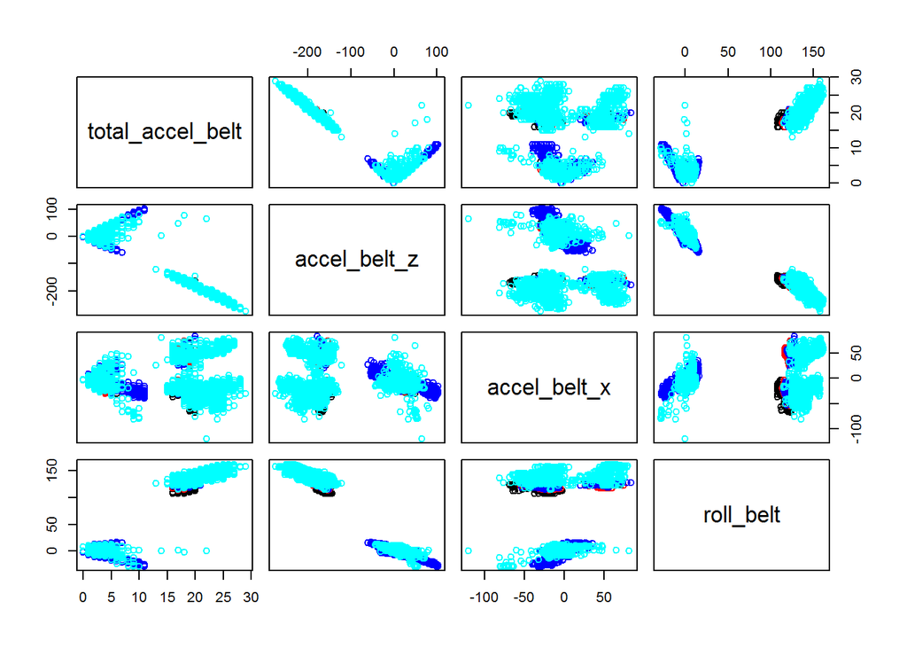

```r
pairs(traindat[,c(4,10,8,1)], col = traindat$classe)
```

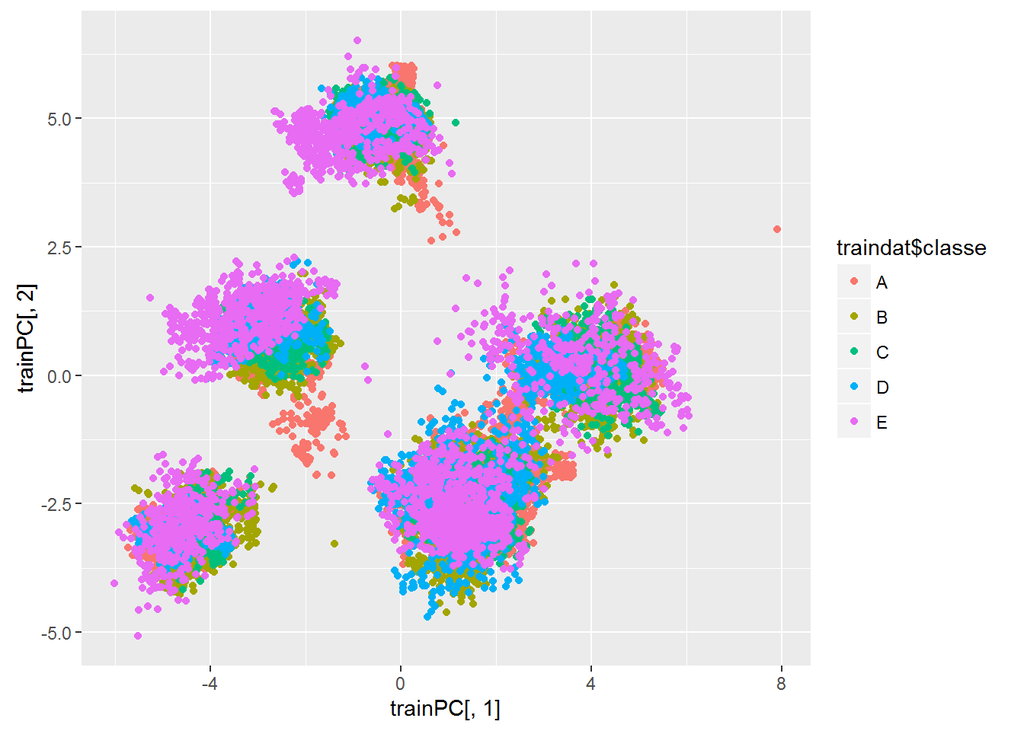

```r
preProc <- preProcess(traindat[,-53], method="pca",pcaComp=2)
trainPC <- predict(preProc,traindat[,-53])
qplot(trainPC[,1],trainPC[,2],col=traindat$classe)
```

Using any kind of linear regression or PCA analysis seems to do a poor job separating data clusters by classe

Use randomforest algorithm to run training model predictions, with an out of bag method of drawing data.

```r
set.seed(314)
tc <- trainControl(method = "oob", number = 5, p = 0.8,  allowParallel = TRUE)
modelfit <- train(classe ~., method = "rf", data = traindat, trControl = tc, prox = TRUE)

modelfit$finalModel
```

```
##
## Call:
##  randomForest(x = x, y = y, mtry = param$mtry, proximity = TRUE)
##                Type of random forest: classification
##                      Number of trees: 500
## No. of variables tried at each split: 2
##
##         OOB estimate of  error rate: 0.6%
## Confusion matrix:
##      A    B    C    D    E  class.error
## A 4463    1    0    0    0 0.0002240143
## B   15 3019    4    0    0 0.0062541145
## C    0   18 2718    2    0 0.0073046019
## D    0    0   44 2526    3 0.0182666148
## E    0    0    1    6 2879 0.0024255024
```

```r
pred <- predict(modelfit,testdat)
table(pred,testdat$classe)
```

```
##
## pred    A    B    C    D    E
##    A 1116    7    0    0    0
##    B    0  752    3    0    0
##    C    0    0  681    9    0
##    D    0    0    0  633    1
##    E    0    0    0    1  720
```

```r
confusionMatrix(testdat$classe,pred)
```

```
## Confusion Matrix and Statistics
##
##           Reference
## Prediction    A    B    C    D    E
##          A 1116    0    0    0    0
##          B    7  752    0    0    0
##          C    0    3  681    0    0
##          D    0    0    9  633    1
##          E    0    0    0    1  720
##
## Overall Statistics
##
##                Accuracy : 0.9946
##                  95% CI : (0.9918, 0.9967)
##     No Information Rate : 0.2863
##     P-Value [Acc > NIR] : < 2.2e-16
##
##                   Kappa : 0.9932
##  Mcnemar's Test P-Value : NA
##
## Statistics by Class:
##
##                      Class: A Class: B Class: C Class: D Class: E
## Sensitivity            0.9938   0.9960   0.9870   0.9984   0.9986
## Specificity            1.0000   0.9978   0.9991   0.9970   0.9997
## Pos Pred Value         1.0000   0.9908   0.9956   0.9844   0.9986
## Neg Pred Value         0.9975   0.9991   0.9972   0.9997   0.9997
## Prevalence             0.2863   0.1925   0.1759   0.1616   0.1838
## Detection Rate         0.2845   0.1917   0.1736   0.1614   0.1835
## Detection Prevalence   0.2845   0.1935   0.1744   0.1639   0.1838
## Balanced Accuracy      0.9969   0.9969   0.9930   0.9977   0.9992
```

for testing submission

```r
pred <- predict(modelfit,test)
answers <- pred

pml_write_files = function(x){
  n = length(x)
  for(i in 1:n){
    filename = paste0("problem_id_",i,".txt")
    write.table(x[i],file=filename,quote=FALSE,row.names=FALSE,col.names=FALSE)
  }
}

pml_write_files(answers)
```